# Cyclistic Case Study

2022-12-20

## Introduction

In this case-study, I worked for the fictional company Cyclistic as a Junior Data Analyst. The director of marketing believes the company’s future success depends on maximizing the number of annual memberships. My team wants to understand how casual riders and annual members use Cyclistic bikes differently. From these insights, my team will design a new marketing strategy to convert casual riders into annual members. But first, Cyclistic executives must approve my recommendations, so they must be backed up with compelling data insights and professional data visualizations.

### About The Comapany

In 2016, Cyclistic launched a successful bike-share offering. Since then, the program has grown to a fleet of 5,824 bicycles that are geotracked and locked into a network of 692 stations across Chicago. The bikes can be unlocked from one station and returned to any other station in the system anytime.

Until now, Cyclistic’s marketing strategy relied on building general awareness and appealing to broad consumer segments. One approach that helped make these things possible was the flexibility of its pricing plans: single-ride passes, full-day passes, and annual memberships. Customers who purchase single-ride or full-day passes are referred to as casual riders. Customers who purchase annual memberships are Cyclistic members. Cyclistic’s finance analysts have concluded that annual members are much more profitable than casual riders. Although the pricing flexibility helps Cyclistic attract more customers, Moreno believes that maximizing the number of annual members will be key to future growth. Rather than creating a marketing campaign that targets all-new customers, Moreno believes there is a very good chance to convert casual riders into members. She notes that casual riders are already aware of the Cyclistic program and have chosen Cyclistic for their mobility needs.

Moreno has set a clear goal: Design marketing strategies aimed at converting casual riders into annual members. In order to do that, however, the marketing analyst team needs to better understand how annual members and casual riders differ, why casual riders would buy a membership, and how digital media could affect their marketing tactics. Moreno and her team are interested in analyzing the Cyclistic historical bike trip data to identify trends.

## Ask

Three questions will guide the future marketing program: 1. How do annual members and casual riders use Cyclistic bikes differently? 2. Why would casual riders buy Cyclistic annual memberships? 3. How can Cyclistic use digital media to influence casual riders to become members?

### Business Task

Moreno has assigned you the first question to answer:**How do annual members and casual riders use Cyclistic bikes differently?**

### Key Stakeholders

The key stakeholders are Lily Moreno, the Executive team, and the Marketing Analytics team.

## Prepare

First I downloaded the data from the past 12 months (December 2021 - November 2022) onto my computer as CSV files. Each file has 13 columns.The data has been made available by Motivate International Inc. under this [license](https://ride.divvybikes.com/data-license-agreement). The data was collected first-party and therefore should be reliable.

## Process

The following code was run in RStudio:

First load in necessary packages.

```r
install.packages('tidyverse', repos = "http://cran.us.r-project.org")
install.packages('lubridate', repos = "http://cran.us.r-project.org")
library(tidyverse)
library(lubridate)
```

Now read in the data for each month.

```r
#load in the data

y2021_12 <- read.csv("202112-divvy-tripdata.csv")
y2022_01 <- read.csv("202201-divvy-tripdata.csv")
y2022_02 <- read.csv("202202-divvy-tripdata.csv")
y2022_03 <- read.csv("202203-divvy-tripdata.csv")
y2022_04 <- read.csv("202204-divvy-tripdata.csv")
y2022_05 <- read.csv("202205-divvy-tripdata.csv")
y2022_06 <- read.csv("202206-divvy-tripdata.csv")
y2022_07 <- read.csv("202207-divvy-tripdata.csv")
y2022_08 <- read.csv("202208-divvy-tripdata.csv")
y2022_09 <- read.csv("202209-divvy-publictripdata.csv")
y2022_10 <- read.csv("202210-divvy-tripdata.csv")
y2022_11 <- read.csv("202211-divvy-tripdata.csv")
```

Each data set can be viewed to confirm that they have the same number of columns and column names.

Removed columns not needed from each data set. The columns start_station_name,start_station_id,end_station_name, and end_station_id have missing values and the information is redundant with start_lat, start_lng, end_lat, and end_lng. Identifying specific rides will not be needed so I also removed the column ride_id.

```r
y2021_12 <- y2021_12 %>% select(-c(ride_id,start_station_name,start_station_id,end_station_name,end_station_id))
y2022_01 <- y2022_01 %>% select(-c(ride_id,start_station_name,start_station_id,end_station_name,end_station_id))
y2022_02 <- y2022_02 %>% select(-c(ride_id,start_station_name,start_station_id,end_station_name,end_station_id))
y2022_03 <- y2022_03 %>% select(-c(ride_id,start_station_name,start_station_id,end_station_name,end_station_id))
y2022_04 <- y2022_04 %>% select(-c(ride_id,start_station_name,start_station_id,end_station_name,end_station_id))
y2022_05 <- y2022_05 %>% select(-c(ride_id,start_station_name,start_station_id,end_station_name,end_station_id))
y2022_06 <- y2022_06 %>% select(-c(ride_id,start_station_name,start_station_id,end_station_name,end_station_id))
y2022_07 <- y2022_07 %>% select(-c(ride_id,start_station_name,start_station_id,end_station_name,end_station_id))
y2022_08 <- y2022_08 %>% select(-c(ride_id,start_station_name,start_station_id,end_station_name,end_station_id))
y2022_09 <- y2022_09 %>% select(-c(ride_id,start_station_name,start_station_id,end_station_name,end_station_id))
y2022_10 <- y2022_10 %>% select(-c(ride_id,start_station_name,start_station_id,end_station_name,end_station_id))
y2022_11 <- y2022_11 %>% select(-c(ride_id,start_station_name,start_station_id,end_station_name,end_station_id))
```

Now combine all the data tables into one table to speed up analysis.

```r
#combine data frames into one data table

all_rides <- bind_rows(y2021_12, y2022_01, y2022_02, y2022_03, y2022_04, y2022_05, y2022_06, y2022_07, y2022_08, y2022_09, y2022_10, y2022_11)
```

Create columns for analysis to compare month and day of the week.

```r
 # create columns for year, month, and date.
all_rides$date <- as.Date(all_rides$started_at) #column created to extract over values from.
all_rides$year <- format(all_rides$date, '%y')
all_rides$month <- format(all_rides$date, '%m')
all_rides$day <- format(all_rides$date, '%d')
all_rides$day_of_week <- wday(all_rides$date, week_start = 1) #take the numeric day of the month column and turns in into a day of the week column, with 1 being Monday.

all_rides <- all_rides %>% select(-c(date)) #remove the date column since we can do comparisons using the month and day_of_week columns.
```

Now we will calculate the length of a ride in minutes and store this in its own column. Some rides will have negative length which we can remove. Docked bikes are not a ridable type and can also be removed from analysis.

```r
#create a column for length of ride

all_rides$trip_length <- difftime(all_rides$ended_at, all_rides$started_at, units = "mins")
head(all_rides)
```

```
##   rideable_type          started_at            ended_at start_lat start_lng
## 1 electric_bike 2021-12-07 15:06:07 2021-12-07 15:13:42  41.85483 -87.66366
## 2 electric_bike 2021-12-11 03:43:29 2021-12-11 04:10:23  41.89441 -87.63233
## 3 electric_bike 2021-12-15 23:10:28 2021-12-15 23:23:14  41.89936 -87.64852
## 4  classic_bike 2021-12-26 16:16:10 2021-12-26 16:30:53  41.89939 -87.64854
## 5 electric_bike 2021-12-30 11:31:05 2021-12-30 11:51:21  41.89558 -87.68202
## 6  classic_bike 2021-12-01 18:28:36 2021-12-01 18:38:03  41.86038 -87.62581
##    end_lat   end_lng member_casual year month day day_of_week    trip_length
## 1 41.87197 -87.65097        member   21    12  07           2  7.583333 mins
## 2 41.96797 -87.65000        casual   21    12  11           6 26.900000 mins
## 3 41.93758 -87.64410        member   21    12  15           3 12.766667 mins
## 4 41.89488 -87.63233        member   21    12  26           7 14.716667 mins
## 5 41.93125 -87.64434        member   21    12  30           4 20.266667 mins
## 6 41.87260 -87.63350        member   21    12  01           3  9.450000 mins
```

```r
#Remove docked bikes and entries with negative ride time

all_rides_v2 <- all_rides[!(all_rides$rideable_type == 'docked_bike' | all_rides$trip_length < 0),]  #creates a new table without negative ride times and docked bikes entries
View(all_rides_v2) #preview our data before analysis.
```

## Analyze

Now that we have prepared our data we can analyze it.

First, compare the trip length for members and casual riders.

```r
mean(all_rides_v2[all_rides_v2$member_casual == 'member', 'trip_length'])
```

```
## Time difference of 12.70938 mins
```

```r
mean(all_rides_v2[all_rides_v2$member_casual == 'casual', 'trip_length'])
```

```
## Time difference of 21.4554 mins
```

From this we see that casual riders have longer trips on average. We can also compare the average ride length for each member type by the different days of the week.

```r
aggregate(all_rides_v2$trip_length ~ all_rides_v2$member_casual+all_rides_v2$day_of_week, FUN = mean)
```

```
##    all_rides_v2$member_casual all_rides_v2$day_of_week all_rides_v2$trip_length
## 1                      casual                        1            21.59141 mins
## 2                      member                        1            12.27358 mins
## 3                      casual                        2            19.54815 mins
## 4                      member                        2            12.14777 mins
## 5                      casual                        3            18.82535 mins
## 6                      member                        3            12.06597 mins
## 7                      casual                        4            19.34402 mins
## 8                      member                        4            12.29975 mins
## 9                      casual                        5            20.50277 mins
## 10                     member                        5            12.50004 mins
## 11                     casual                        6            23.78574 mins
## 12                     member                        6            14.15030 mins
## 13                     casual                        7            24.34993 mins
## 14                     member                        7            14.05238 mins
```

1 corresponds to Monday and 7 to Sunday. From this we can see that casual members have the longest and largest number of trips on the weekends. Most members are taking trips during the weekday, indicating a number of employees using bikes to commute to work.

```r
#rideship data by type and weekday
all_rides_v2 %>%
  mutate(weekday = wday(started_at, week_start = 1)) %>%  #creates weekday field using wday()
  group_by(member_casual, weekday) %>%  #groups by usertype and weekday
  summarise(number_of_rides = n()                           #calculates the number of rides and average duration
            ,average_duration = mean(trip_length)) %>%      # calculates the average duration
  arrange(member_casual, weekday)
```

```
## # A tibble: 14 × 4
## # Groups:   member_casual [2]
##    member_casual weekday number_of_rides average_duration
##    <chr>           <dbl>           <int> <drtn>
##  1 casual              1          257559 21.59141 mins
##  2 casual              2          246187 19.54815 mins
##  3 casual              3          261600 18.82535 mins
##  4 casual              4          293543 19.34402 mins
##  5 casual              5          316554 20.50277 mins
##  6 casual              6          434993 23.78574 mins
##  7 casual              7          355908 24.34993 mins
##  8 member              1          476931 12.27358 mins
##  9 member              2          518657 12.14777 mins
## 10 member              3          537743 12.06597 mins
## 11 member              4          540341 12.29975 mins
## 12 member              5          476905 12.50004 mins
## 13 member              6          445466 14.15030 mins
## 14 member              7          390487 14.05238 mins
```

These trends are best displayed as a graph, where we can see that casual riders and members differ the most in the number of rides on weekdays, while on weekends they are roughly equal.

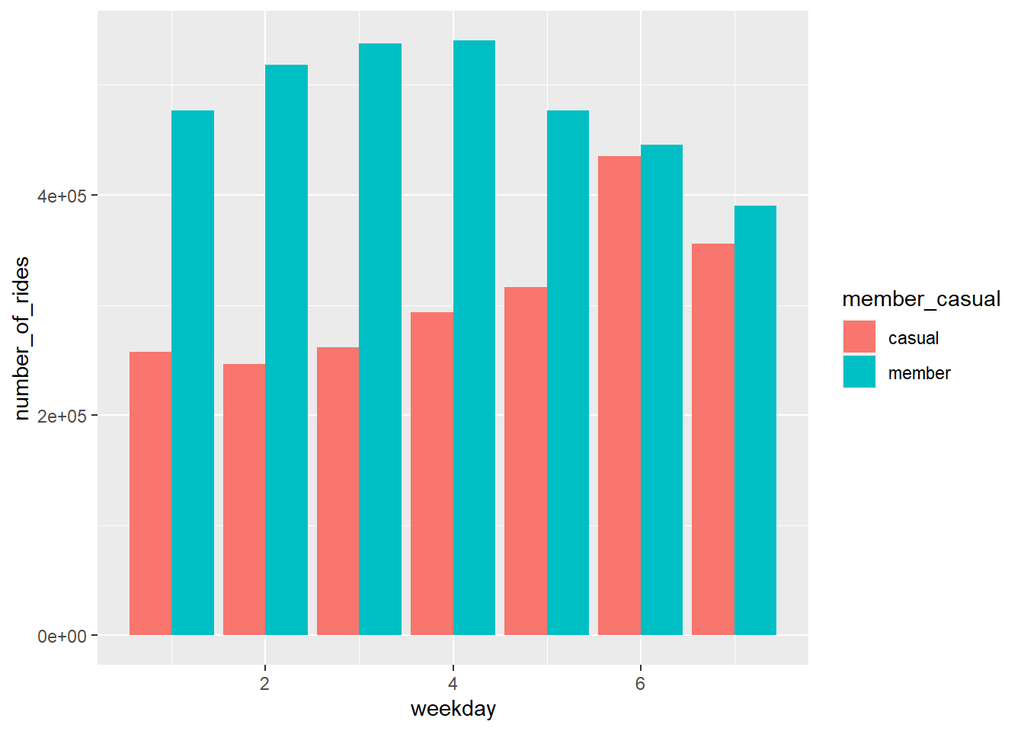

```r
#number of rides by type for each day of the week. 1 = Monday, 7 = Sunday
all_rides_v2 %>%
  mutate(weekday = wday(started_at, week_start = 1)) %>%
  group_by(member_casual, weekday) %>%
  summarise(number_of_rides = n()
            ,average_duration = mean(trip_length)) %>%
  arrange(member_casual, weekday)  %>%
  ggplot(aes(x = weekday, y = number_of_rides, fill = member_casual)) +
  geom_col(position = "dodge")
```

```
## Defaulting to continuous.
```

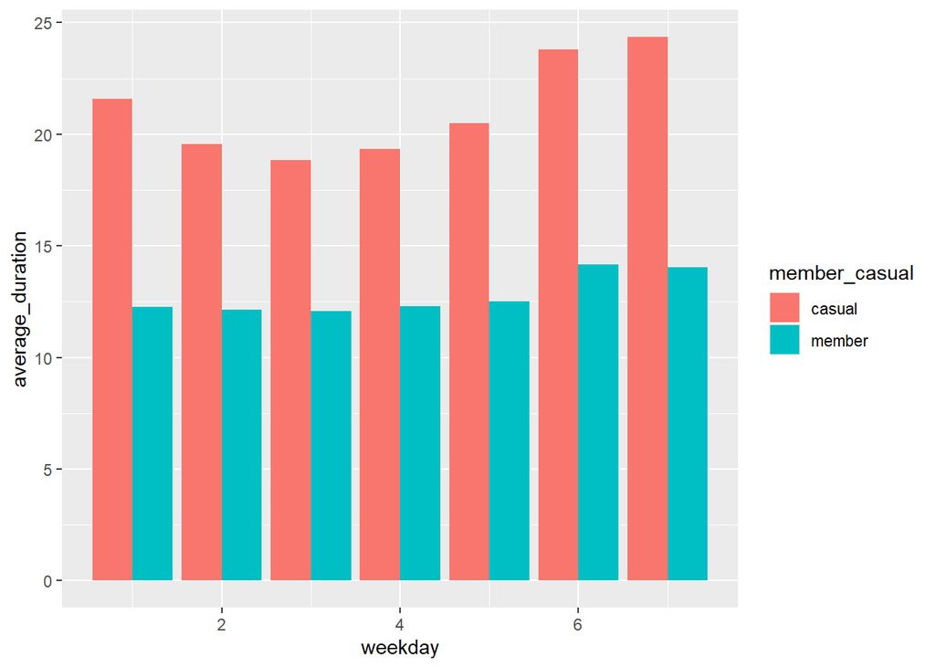

```r
#average trip duration by week day for casual riders and members

all_rides_v2 %>%
  mutate(weekday = wday(started_at, week_start = 1)) %>%
  group_by(member_casual, weekday) %>%
  summarise(number_of_rides = n()
            ,average_duration = mean(trip_length)) %>%
  arrange(member_casual, weekday)  %>%
  ggplot(aes(x = weekday, y = average_duration, fill = member_casual)) +
  geom_col(position = "dodge")
```

Here we can see that casual riders are riding for a much longer duration than members for every day of the week, but ride the longest on the weekends.

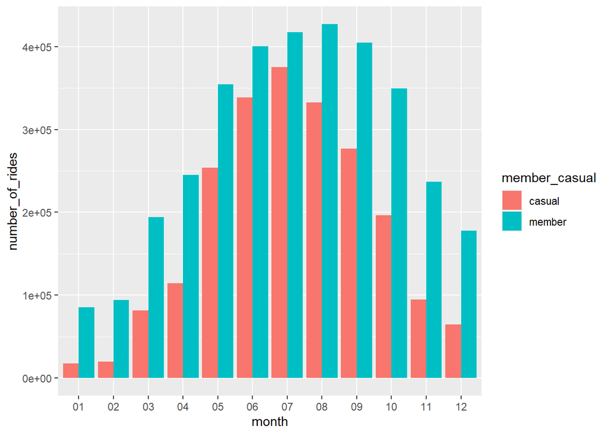

```r
#number of rides by type for each month in the year

all_rides_v2 %>%
  group_by(member_casual, month) %>%
  summarise(number_of_rides = n()
            ,average_duration = mean(trip_length)) %>%
  arrange(member_casual, month)  %>%
  ggplot(aes(x = month, y = number_of_rides, fill = member_casual)) +
  geom_col(position = "dodge")
```

Both types of riders see the most trips during the summer, with the fewest the winter months at the start of the year.

Further data analysis was done using Tableau, which can be viewed [here](https://public.tableau.com/app/profile/brandon.a.abrego/viz/Cyclistic_16714077823120/Dashboard1). From Tableau I found that both riders use electric bikes more, but the number of riders using classic bikes is still significant. This indicates that casual riders using classic bikes are more likely riding for fitness reasons and casual riders using electric bikes are more likely riding for sight-seeing.

## Summary

Based on my analysis, casual riders and members differ mostly since some of members use bikes for their daily commutes to work. Members opt for this since their work is relatively close indicated by the shorter average travel time. Casual riders are riding for leisure To convert casual riders to members, I suggest the following:

1. Focus advertising at the start of the summer to encourage casual members to get annual memberships
2. Create a health tracker available to members to track their progress and meet fitness goals.
3. Offer reward points for trips and distance traveled that can be redeemed for small discounts at stores in the area.

### Further Analysis

Additional analysis can be done using coordinates to determine the most popular locations and destinations. Data on the inventory of each docking station can further be used to determine if certain stations are frequently missing bikes which deters casual riders from getting an annual membership.